# Parcial1

Usando la misma matriz de Adyacencia usada en clase para el grafo de comunas/corregimientos de Medellín (tambien lo pueden encontrar en Interactiva) construya la matriz de Adyacencia.

```python
import numpy as np
A = np.array([[0, 1, 1, 1, 0, 0, 0, 0, 0, 0, 0, 0, 0, 0, 0, 0, 0, 0, 0, 0, 1], # 01 Popular
     [1, 0, 0, 1, 1, 0, 0, 0, 0, 0, 0, 0, 0, 0, 0, 0, 0, 0, 0, 0, 0], # 02 Santa Cruz
     [1, 0, 0, 1, 0, 0, 0, 1, 0, 0, 0, 0, 0, 0, 0, 0, 0, 0, 0, 0, 1], # 03 Manrique
     [1, 1, 1, 0, 1, 0, 0, 1, 0, 1, 0, 0, 0, 0, 0, 0, 0, 0, 0, 0, 0], # 04 Aranjuez
     [0, 1, 0, 1, 0, 1, 1, 0, 0, 0, 0, 0, 0, 0, 0, 0, 0, 0, 0, 0, 0], # 05 Castilla
     [0, 0, 0, 0, 1, 0, 1, 0, 0, 0, 0, 0, 0, 0, 0, 0, 0, 1, 0, 0, 0], # 06 12 de Octubre
     [0, 0, 0, 0, 1, 1, 0, 0, 0, 1, 1, 1, 1, 0, 0, 0, 0, 1, 0, 0, 0], # 07 Robledo
     [0, 0, 1, 1, 0, 0, 0, 0, 1, 1, 0, 0, 0, 0, 0, 0, 0, 0, 0, 0, 1], # 08 Villa Hermosa
     [0, 0, 0, 0, 0, 0, 0, 1, 0, 1, 0, 0, 0, 1, 0, 0, 0, 0, 0, 0, 1], # 09 Buenos Aires
     [0, 0, 0, 1, 0, 0, 1, 1, 1, 0, 1, 0, 0, 1, 0, 1, 0, 0, 0, 0, 0], # 10 La Candelaria
     [0, 0, 0, 0, 0, 0, 1, 0, 0, 1, 0, 1, 0, 0, 0, 1, 0, 0, 0, 0, 0], # 11 Laureles-Estadio
     [0, 0, 0, 0, 0, 0, 1, 0, 0, 0, 1, 0, 1, 0, 0, 1, 0, 0, 0, 0, 0], # 12 La Ameria
     [0, 0, 0, 0, 0, 0, 1, 0, 0, 0, 0, 1, 0, 0, 0, 0, 0, 1, 1, 0, 0], # 13 San Javier
     [0, 0, 0, 0, 0, 0, 0, 0, 1, 1, 0, 0, 0, 0, 1, 0, 0, 0, 0, 0, 1], # 14 Poblado
     [0, 0, 0, 0, 0, 0, 0, 0, 0, 0, 0, 0, 0, 1, 0, 1, 0, 0, 1, 0, 0], # 15 Guayabal
     [0, 0, 0, 0, 0, 0, 0, 0, 0, 1, 1, 1, 0, 0, 1, 0, 0, 0, 1, 0, 0], # 16 Belen
     [0, 0, 0, 0, 0, 0, 0, 0, 0, 0, 0, 0, 0, 0, 0, 0, 0, 1, 0, 1, 0], # 50 Palmitas
     [0, 0, 0, 0, 0, 1, 1, 0, 0, 0, 0, 0, 1, 0, 0, 0, 1, 0, 1, 1, 0], # 60 San Cristobal
     [0, 0, 0, 0, 0, 0, 0, 0, 0, 0, 0, 0, 1, 0, 1, 1, 0, 1, 0, 1, 0], # 70 Altavista
     [0, 0, 0, 0, 0, 0, 0, 0, 0, 0, 0, 0, 0, 0, 0, 0, 1, 1, 1, 0, 0], # 80 Prado
     [1, 0, 1, 0, 0, 0, 0, 1, 1, 0, 0, 0, 0, 1, 0, 0, 0, 0, 0, 0, 0], # 90 Santa Elena
     ])
```

Use la tabla hurto a personas por comuna/corregimiento del Informe Semanal de Hurtos en Medellín. Para cada comuna 𝑖, defina su indicador estandarizado de la forma.

H_i_gorro=hi-h_gorro/Sh

hi_=cantidad de hurtos

h_gorro=media

Sh=desviacion estandar de hurtos por comuna/corregimiento

```python
import numpy as np
hurtos = [
    18,   # 01 Popular
    11,   # 02 Santa Cruz
    36,   # 03 Manrique
    79,   # 04 Aranjuez
    87,   # 05 Castilla
    33,   # 06 Doce de Octubre
    74,   # 07 Robledo
    29,   # 08 Villa Hermosa
    88,   # 09 Buenos Aires
    456,  # 10 La Candelaria
    276,  # 11 Laureles Estadio
    42,   # 12 La América
    35,   # 13 San Javier
    252,  # 14 El Poblado
    72,   # 15 Guayabal
    101,  # 16 Belén
    1,    # 50 San Sebastián de Palmitas
    25,   # 60 San Cristóbal
    15,   # 70 Altavista
    11,   # 80 San Antonio de Prado
    15    # 90 Santa Elena
]
hi=np.array(hurtos)
h_gorro=np.mean(hi)
Sh=np.std(hi)
H_i_gorro=(hi-h_gorro)/Sh
print("Promedio de hurtos por comuna/corregimiento: ",h_gorro)
print(f"Indicador estandarizado de hurtos por comuna/corregimiento: {H_i_gorro}")

print(len(A))
```

```
Promedio de hurtos por comuna/corregimiento:  83.61904761904762
Indicador estandarizado de hurtos por comuna/corregimiento: [-0.60014598 -0.66416736 -0.43551958 -0.0422454   0.03092189 -0.46295732
 -0.08797496 -0.49954096  0.0400678   3.40576313  1.75949911 -0.38064411
 -0.44466549  1.53999724 -0.10626678  0.15896465 -0.75562647 -0.5361246
 -0.62758372 -0.66416736 -0.62758372]
21
```

[figure not shown]

```python
# Crear matriz de pesos W como array de NumPy
W = np.zeros((len(A), len(A)), dtype=np.float64)
sigma = 1

for i in range(len(A)):
    for j in range(len(A)):
        if A[i,j] == 1:
            diferencia = H_i_gorro[i] - H_i_gorro[j]
            # Fórmula correcta: exp(-((h_i - h_j)^2) / (2 * sigma^2))
            W[i,j] = np.exp(-(diferencia**2) / (2 * sigma**2))
        else:
            W[i,j] = 0

print(f"Número de aristas con peso no cero: {np.count_nonzero(W)}")
print("\nMatriz de pesos W:")
print(W)
```

```
Número de aristas con peso no cero: 92

Matriz de pesos W:
[[0.     0.998  0.9865 0.8559 0.     0.     0.     0.     0.     0.     0.     0.     0.     0.     0.     0.
  0.     0.     0.     0.     0.9996]
 [0.998  0.     0.     0.8242 0.7854 0.     0.     0.     0.     0.     0.     0.     0.     0.     0.     0.
  0.     0.     0.     0.     0.    ]
 [0.9865 0.     0.     0.9256 0.     0.     0.     0.998  0.     0.     0.     0.     0.     0.     0.     0.
  0.     0.     0.     0.     0.9817]
 [0.8559 0.8242 0.9256 0.     0.9973 0.     0.     0.9007 0.     0.0026 0.     0.     0.     0.     0.     0.
  0.     0.     0.     0.     0.    ]
 [0.     0.7854 0.     0.9973 0.     0.8852 0.993  0.     0.     0.     0.     0.     0.     0.     0.     0.
  0.     0.     0.     0.     0.    ]
 [0.     0.     0.     0.     0.8852 0.     0.9321 0.     0.     0.     0.     0.     0.     0.     0.     0.
  0.     0.9973 0.     0.     0.    ]
 [0.     0.     0.     0.     0.993  0.9321 0.     0.     0.     0.0022 0.1815 0.9581 0.9384 0.     0.     0.
  0.     0.9045 0.     0.     0.    ]
 [0.     0.     0.998  0.9007 0.     0.     0.     0.     0.8645 0.0005 0.     0.     0.     0.     0.     0.
  0.     0.     0.     0.     0.9918]
 [0.     0.     0.     0.     0.     0.     0.     0.8645 0.     0.0035 0.     0.     0.     0.3247 0.     0.
  0.     0.     0.     0.     0.8002]
 [0.     0.     0.     0.0026 0.     0.     0.0022 0.0005 0.0035 0.     0.2579 0.     0.     0.1754 0.     0.0051
  0.     0.     0.     0.     0.    ]
 [0.     0.     0.     0.     0.     0.     0.1815 0.     0.     0.2579 0.     0.1013 0.     0.     0.     0.2778
  0.     0.     0.     0.     0.    ]
 [0.     0.     0.     0.     0.     0.     0.9581 0.     0.     0.     0.1013 0.     0.998  0.     0.     0.8645
  0.     0.     0.     0.     0.    ]
 [0.     0.     0.     0.     0.     0.     0.9384 0.     0.     0.     0.     0.998  0.     0.     0.     0.
  0.     0.9958 0.9834 0.     0.    ]
 [0.     0.     0.     0.     0.     0.     0.     0.     0.3247 0.1754 0.     0.     0.     0.     0.2579 0.
  0.     0.     0.     0.     0.0954]
 [0.     0.     0.     0.     0.     0.     0.     0.     0.     0.     0.     0.     0.     0.2579 0.     0.9654
  0.     0.     0.8729 0.     0.    ]
 [0.     0.     0.     0.     0.     0.     0.     0.     0.     0.0051 0.2778 0.8645 0.     0.     0.9654 0.
  0.     0.     0.7339 0.     0.    ]
 [0.     0.     0.     0.     0.     0.     0.     0.     0.     0.     0.     0.     0.     0.     0.     0.
  0.     0.9762 0.     0.9958 0.    ]
 [0.     0.     0.     0.     0.     0.9973 0.9045 0.     0.     0.     0.     0.     0.9958 0.     0.     0.
  0.9762 0.     0.9958 0.9918 0.    ]
 [0.     0.     0.     0.     0.     0.     0.     0.     0.     0.     0.     0.     0.9834 0.     0.8729 0.7339
  0.     0.9958 0.     0.9993 0.    ]
 [0.     0.     0.     0.     0.     0.     0.     0.     0.     0.     0.     0.     0.     0.     0.     0.
  0.9958 0.9918 0.9993 0.     0.    ]
 [0.9996 0.     0.9817 0.     0.     0.     0.     0.9918 0.8002 0.     0.     0.     0.     0.0954 0.     0.
  0.     0.     0.     0.     0.    ]]
```

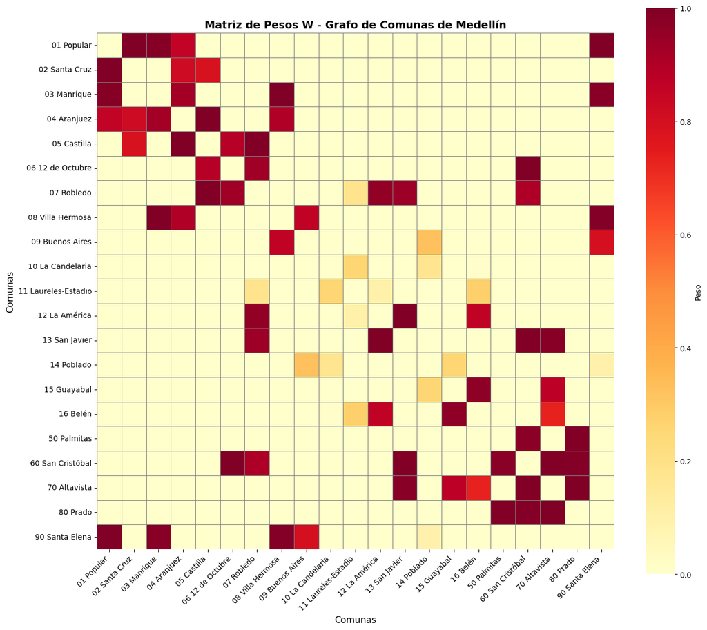

```python
# Visualización gráfica con heatmap
import matplotlib.pyplot as plt
import seaborn as sns

# Nombres de las comunas
comunas = [
    "01 Popular", "02 Santa Cruz", "03 Manrique", "04 Aranjuez", "05 Castilla",
    "06 12 de Octubre", "07 Robledo", "08 Villa Hermosa", "09 Buenos Aires", "10 La Candelaria",
    "11 Laureles-Estadio", "12 La América", "13 San Javier", "14 Poblado", "15 Guayabal",
    "16 Belén", "50 Palmitas", "60 San Cristóbal", "70 Altavista", "80 Prado", "90 Santa Elena"
]

# Configurar estilo
plt.figure(figsize=(14, 12))
sns.heatmap(W,
            annot=False,  # Cambiar a True si quieres ver los valores en cada celda
            fmt='.3f',
            cmap='YlOrRd',  # Colormap: puedes usar 'viridis', 'plasma', 'coolwarm', etc.
            cbar_kws={'label': 'Peso'},
            square=True,
            linewidths=0.5,
            linecolor='gray',
            xticklabels=comunas,
            yticklabels=comunas,
            vmin=0,
            vmax=1)

plt.title('Matriz de Pesos W - Grafo de Comunas de Medellín', fontsize=14, fontweight='bold')
plt.xlabel('Comunas', fontsize=12)
plt.ylabel('Comunas', fontsize=12)
plt.xticks(rotation=45, ha='right')
plt.yticks(rotation=0)
plt.tight_layout()
plt.show()
```

[figure not shown]

```python
D=np.diag(np.sum(W,axis=1))
D_inv_sqrt = np.diag(1 / np.sqrt(np.diag(D)))
L = np.eye(len(W)) - D_inv_sqrt @ W @ D_inv_sqrt
L
```

```
array([[ 1.    , -0.3154, -0.2552, -0.2057,  0.    ,  0.    ,  0.    ,  0.    ,  0.    ,  0.    ,  0.    ,  0.    ,
         0.    ,  0.    ,  0.    ,  0.    ,  0.    ,  0.    ,  0.    ,  0.    , -0.2593],
       [-0.3154,  1.    ,  0.    , -0.2404, -0.2542,  0.    ,  0.    ,  0.    ,  0.    ,  0.    ,  0.    ,  0.    ,
         0.    ,  0.    ,  0.    ,  0.    ,  0.    ,  0.    ,  0.    ,  0.    ,  0.    ],
       [-0.2552,  0.    ,  1.    , -0.221 ,  0.    ,  0.    ,  0.    , -0.261 ,  0.    ,  0.    ,  0.    ,  0.    ,
         0.    ,  0.    ,  0.    ,  0.    ,  0.    ,  0.    ,  0.    ,  0.    , -0.253 ],
       [-0.2057, -0.2404, -0.221 ,  1.    , -0.2455,  0.    ,  0.    , -0.219 ,  0.    , -0.0018,  0.    ,  0.    ,
         0.    ,  0.    ,  0.    ,  0.    ,  0.    ,  0.    ,  0.    ,  0.    ,  0.    ],
       [ 0.    , -0.2542,  0.    , -0.2455,  1.    , -0.2758, -0.2342,  0.    ,  0.    ,  0.    ,  0.    ,  0.    ,
         0.    ,  0.    ,  0.    ,  0.    ,  0.    ,  0.    ,  0.    ,  0.    ,  0.    ],
       [ 0.    ,  0.    ,  0.    ,  0.    , -0.2758,  1.    , -0.2507,  0.    ,  0.    ,  0.    ,  0.    ,  0.    ,
         0.    ,  0.    ,  0.    ,  0.    ,  0.    , -0.2455,  0.    ,  0.    ,  0.    ],
       [ 0.    ,  0.    ,  0.    ,  0.    , -0.2342, -0.2507,  1.    ,  0.    ,  0.    , -0.0015, -0.0905, -0.253 ,
        -0.214 ,  0.    ,  0.    ,  0.    ,  0.    , -0.1686,  0.    ,  0.    ,  0.    ],
       [ 0.    ,  0.    , -0.261 , -0.219 ,  0.    ,  0.    ,  0.    ,  1.    , -0.316 , -0.0004,  0.    ,  0.    ,
         0.    ,  0.    ,  0.    ,  0.    ,  0.    ,  0.    ,  0.    ,  0.    , -0.2602],
       [ 0.    ,  0.    ,  0.    ,  0.    ,  0.    ,  0.    ,  0.    , -0.316 ,  1.    , -0.0037,  0.    ,  0.    ,
         0.    , -0.249 ,  0.    ,  0.    ,  0.    ,  0.    ,  0.    ,  0.    , -0.2882],
       [ 0.    ,  0.    ,  0.    , -0.0018,  0.    ,  0.    , -0.0015, -0.0004, -0.0037,  1.    , -0.4263,  0.    ,
         0.    , -0.2839,  0.    , -0.0046,  0.    ,  0.    ,  0.    ,  0.    ,  0.    ],
       [ 0.    ,  0.    ,  0.    ,  0.    ,  0.    ,  0.    , -0.0905,  0.    ,  0.    , -0.4263,  1.    , -0.0655,
         0.    ,  0.    ,  0.    , -0.182 ,  0.    ,  0.    ,  0.    ,  0.    ,  0.    ],
       [ 0.    ,  0.    ,  0.    ,  0.    ,  0.    ,  0.    , -0.253 ,  0.    ,  0.    ,  0.    , -0.0655,  1.    ,
        -0.295 ,  0.    ,  0.    , -0.2998,  0.    ,  0.    ,  0.    ,  0.    ,  0.    ],
       [ 0.    ,  0.    ,  0.    ,  0.    ,  0.    ,  0.    , -0.214 ,  0.    ,  0.    ,  0.    ,  0.    , -0.295 ,
         1.    ,  0.    ,  0.    ,  0.    ,  0.    , -0.2079, -0.2321,  0.    ,  0.    ],
       [ 0.    ,  0.    ,  0.    ,  0.    ,  0.    ,  0.    ,  0.    ,  0.    , -0.249 , -0.2839,  0.    ,  0.    ,
         0.    ,  1.    , -0.1928,  0.    ,  0.    ,  0.    ,  0.    ,  0.    , -0.0525],
       [ 0.    ,  0.    ,  0.    ,  0.    ,  0.    ,  0.    ,  0.    ,  0.    ,  0.    ,  0.    ,  0.    ,  0.    ,
         0.    , -0.1928,  1.    , -0.3952,  0.    ,  0.    , -0.2816,  0.    ,  0.    ],
       [ 0.    ,  0.    ,  0.    ,  0.    ,  0.    ,  0.    ,  0.    ,  0.    ,  0.    , -0.0046, -0.182 , -0.2998,
         0.    ,  0.    , -0.3952,  1.    ,  0.    ,  0.    , -0.2031,  0.    ,  0.    ],
       [ 0.    ,  0.    ,  0.    ,  0.    ,  0.    ,  0.    ,  0.    ,  0.    ,  0.    ,  0.    ,  0.    ,  0.    ,
         0.    ,  0.    ,  0.    ,  0.    ,  1.    , -0.2871,  0.    , -0.4103,  0.    ],
       [ 0.    ,  0.    ,  0.    ,  0.    ,  0.    , -0.2455, -0.1686,  0.    ,  0.    ,  0.    ,  0.    ,  0.    ,
        -0.2079,  0.    ,  0.    ,  0.    , -0.2871,  1.    , -0.1921, -0.237 ,  0.    ],
       [ 0.    ,  0.    ,  0.    ,  0.    ,  0.    ,  0.    ,  0.    ,  0.    ,  0.    ,  0.    ,  0.    ,  0.    ,
        -0.2321,  0.    , -0.2816, -0.2031,  0.    , -0.1921,  1.    , -0.27  ,  0.    ],
       [ 0.    ,  0.    ,  0.    ,  0.    ,  0.    ,  0.    ,  0.    ,  0.    ,  0.    ,  0.    ,  0.    ,  0.    ,
         0.    ,  0.    ,  0.    ,  0.    , -0.4103, -0.237 , -0.27  ,  1.    ,  0.    ],
       [-0.2593,  0.    , -0.253 ,  0.    ,  0.    ,  0.    ,  0.    , -0.2602, -0.2882,  0.    ,  0.    ,  0.    ,
         0.    , -0.0525,  0.    ,  0.    ,  0.    ,  0.    ,  0.    ,  0.    ,  1.    ]])
```

Usando numpy.linalg.eig, calcule el Vector Fiedler correspondiente al autovector asociado al segundo autovalor más pequeño, y úselo para proponer una división del grafo.

```python
vals, vecs = np.linalg.eig(L)
idx = np.argsort(vals)
#print(vals)
#print(idx)
val2=vals[idx[1]]
fiedler=vecs[:,idx[1]]
print(fiedler)

Grupo1=np.where(fiedler<0)[0]
Grupo2=np.where(fiedler>=0)[0]

print(Grupo1)
print(Grupo2)

Comunas=[
    "01 Popular",
    "02 Santa Cruz",
    "03 Manrique",
    "04 Aranjuez",
    "05 Castilla",
    "06 12 de Octubre",
    "07 Robledo",
    "08 Villa Hermosa",
    "09 Buenos Aires",
    "10 La Candelaria",
    "11 Laureles-Estadio",
    "12 La América",
    "13 San Javier",
    "14 Poblado",
    "15 Guayabal",
    "16 Belén",
    "50 Palmitas",
    "60 San Cristóbal",
    "70 Altavista",
    "80 Prado",
    "90 Santa Elena",
]
print([Comunas[i] for i in Grupo1])
print([Comunas[i] for i in Grupo2])
```

```
[-0.3036 -0.1869 -0.3262 -0.2789 -0.05    0.1034  0.1732 -0.3208 -0.219   0.0242  0.0788  0.1855  0.2242 -0.0374
  0.1549  0.1972  0.1825  0.2747  0.2655  0.2254 -0.3299]
[ 0  1  2  3  4  7  8 13 20]
[ 5  6  9 10 11 12 14 15 16 17 18 19]
['01 Popular', '02 Santa Cruz', '03 Manrique', '04 Aranjuez', '05 Castilla', '08 Villa Hermosa', '09 Buenos Aires', '14 Poblado', '90 Santa Elena']
['06 12 de Octubre', '07 Robledo', '10 La Candelaria', '11 Laureles-Estadio', '12 La América', '13 San Javier', '15 Guayabal', '16 Belén', '50 Palmitas', '60 San Cristóbal', '70 Altavista', '80 Prado']
```

Ejercicio Número 2

```python
import numpy as np

import pandas as pd
df=pd.read_csv("tmdb_5000_movies.csv")
df.head()
```

|  | budget | genres | homepage | id | keywords | original_language | original_title | overview | popularity | production_companies | production_countries | release_date | revenue | runtime | spoken_languages | status | tagline | title | vote_average | vote_count |
| --- | --- | --- | --- | --- | --- | --- | --- | --- | --- | --- | --- | --- | --- | --- | --- | --- | --- | --- | --- | --- |
| 0 | 237000000 | [{"id": 28, "name": "Action"}, {"id": 12, "nam... | http://www.avatarmovie.com/ | 19995 | [{"id": 1463, "name": "culture clash"}, {"id":... | en | Avatar | In the 22nd century, a paraplegic Marine is di... | 150.437577 | [{"name": "Ingenious Film Partners", "id": 289... | [{"iso_3166_1": "US", "name": "United States o... | 2009-12-10 | 2787965087 | 162.0 | [{"iso_639_1": "en", "name": "English"}, {"iso... | Released | Enter the World of Pandora. | Avatar | 7.2 | 11800 |
| 1 | 300000000 | [{"id": 12, "name": "Adventure"}, {"id": 14, "... | http://disney.go.com/disneypictures/pirates/ | 285 | [{"id": 270, "name": "ocean"}, {"id": 726, "na... | en | Pirates of the Caribbean: At World's End | Captain Barbossa, long believed to be dead, ha... | 139.082615 | [{"name": "Walt Disney Pictures", "id": 2}, {"... | [{"iso_3166_1": "US", "name": "United States o... | 2007-05-19 | 961000000 | 169.0 | [{"iso_639_1": "en", "name": "English"}] | Released | At the end of the world, the adventure begins. | Pirates of the Caribbean: At World's End | 6.9 | 4500 |
| 2 | 245000000 | [{"id": 28, "name": "Action"}, {"id": 12, "nam... | http://www.sonypictures.com/movies/spectre/ | 206647 | [{"id": 470, "name": "spy"}, {"id": 818, "name... | en | Spectre | A cryptic message from Bond’s past sends him o... | 107.376788 | [{"name": "Columbia Pictures", "id": 5}, {"nam... | [{"iso_3166_1": "GB", "name": "United Kingdom"... | 2015-10-26 | 880674609 | 148.0 | [{"iso_639_1": "fr", "name": "Fran\u00e7ais"},... | Released | A Plan No One Escapes | Spectre | 6.3 | 4466 |
| 3 | 250000000 | [{"id": 28, "name": "Action"}, {"id": 80, "nam... | http://www.thedarkknightrises.com/ | 49026 | [{"id": 849, "name": "dc comics"}, {"id": 853,... | en | The Dark Knight Rises | Following the death of District Attorney Harve... | 112.312950 | [{"name": "Legendary Pictures", "id": 923}, {"... | [{"iso_3166_1": "US", "name": "United States o... | 2012-07-16 | 1084939099 | 165.0 | [{"iso_639_1": "en", "name": "English"}] | Released | The Legend Ends | The Dark Knight Rises | 7.6 | 9106 |
| 4 | 260000000 | [{"id": 28, "name": "Action"}, {"id": 12, "nam... | http://movies.disney.com/john-carter | 49529 | [{"id": 818, "name": "based on novel"}, {"id":... | en | John Carter | John Carter is a war-weary, former military ca... | 43.926995 | [{"name": "Walt Disney Pictures", "id": 2}] | [{"iso_3166_1": "US", "name": "United States o... | 2012-03-07 | 284139100 | 132.0 | [{"iso_639_1": "en", "name": "English"}] | Released | Lost in our world, found in another. | John Carter | 6.1 | 2124 |

2.1 Similaridad por Géneros

• Repesenta cada película como el conjunto de sus géneros (por ejemplo, {Action, Adventure, Science Fiction}).

```python
import numpy as np
import pandas as pd
import json

def obtener_generos(generos_str):
    data=json.loads(generos_str)
    return set(item["name"] for item in data)

df["genres"]=df["genres"].apply(obtener_generos)
#print(df["genres"])
#print(df[df["title"] == "The Matrix Revolutions"][["title","genres"]])
Matix_Generos = df[df["title"] == "The Matrix Revolutions"]["genres"].iloc[0]
print(Matix_Generos)
```

```
{'Adventure', 'Action', 'Thriller', 'Science Fiction'}
```

[figure not shown]

Calcula 𝑑𝐽 entre “The Matrix Revolutions” y todas las demás películas y reporte el top 10 de películas con menos distancia (más similares por genero).

```python
def jaccard_distance(A,B):
    return 1-len(A.intersection(B))/len(A.union(B))

distances = []
i=0
for _, row in df.iterrows():
    i+=1
    if row["title"] == "The Matrix Revolutions":
        continue
    TituloPeliculaActual = row["title"]
    GenerosPeliculaActual = row["genres"]
    distance = jaccard_distance(Matix_Generos, GenerosPeliculaActual)
    distances.append((TituloPeliculaActual, distance, GenerosPeliculaActual))
    distances.sort(key=lambda x: (x[1], x[0]))
top10 = distances[:10]
top=[]
for titulo, distancia, generos in top10:
    print(f"{titulo}: {distancia:.3f}")

for distance in distances:
    if distance[1] == 0.0:
        top.append(distance[0])

print(f"Cantidad de Peliculas con 0: {len(top)}")
```

```
A Sound of Thunder: 0.000
Armageddon: 0.000
Babylon A.D.: 0.000
Battleship: 0.000
Escape from L.A.: 0.000
Firefox: 0.000
G.I. Joe: Retaliation: 0.000
G.I. Joe: The Rise of Cobra: 0.000
Green Lantern: 0.000
I Am Number Four: 0.000
Cantidad de Peliculas con 0: 39
```

2.2 Similaridad por Sinopsis

- Use el campo overview como texto
- defina la función levenshtein_distance(s1, s2) como el mínimo número de ediciones (insertar, borrar, sustituir) para transformar s1 en s2.

```python
import numpy as np

def levenshtein_distance(s1, s2):
    rows = len(s1) + 1
    cols = len(s2) + 1

    dist_matrix = np.zeros((rows, cols), dtype=int)

    # Inicializar primera fila y columna
    for i in range(rows):
        dist_matrix[i, 0] = i
    for j in range(cols):
        dist_matrix[0, j] = j

    # Llenar matriz
    for i in range(1, rows):
        for j in range(1, cols):

            if s1[i-1] == s2[j-1]:
                cost = 0
            else:
                cost = 1

            dist_matrix[i, j] = min(
                dist_matrix[i-1, j] + 1,      # borrar
                dist_matrix[i, j-1] + 1,      # insertar
                dist_matrix[i-1, j-1] + cost  # sustituir
            )

    return dist_matrix[rows-1, cols-1]
```

- Calcule 𝑑𝐿 entre el overview de “The Matrix Revolutions” y el de las demás películas.
- Reporte el top 10 de las películas con menor distancia

```python
Matrix_Overview=str(df[df["title"]=="The Matrix Revolutions"].iloc[0]["overview"])[:150]


# Acotar a 300 filas incluyendo la película de referencia (fila 125)
ref_iloc = 125
start = max(0, ref_iloc - 299)
end = min(len(df), start + 300)
if end - start < 300:
    start = max(0, end - 300)
df_lev = df.iloc[start:end]

distanceslevenshtein = []
for _, row in df_lev.iterrows():
    if row["title"] == "The Matrix Revolutions":
        continue
    title = row["title"]
    overview = str(row["overview"])[:150]
    distance = levenshtein_distance(Matrix_Overview, overview)
    distanceslevenshtein.append((title, distance))
distanceslevenshtein.sort(key=lambda x: (x[1], x[0]))
top10levenshtein = distanceslevenshtein[:10]
for titulo, distancia in top10levenshtein:
    print(f"{titulo}: {distancia:.3f}")
```

```
Jason Bourne: 103.000
Furious 7: 107.000
Noah: 107.000
The Hunger Games: Mockingjay - Part 1: 107.000
X-Men: Days of Future Past: 107.000
Mars Needs Moms: 108.000
Alexander: 109.000
Beowulf: 109.000
Evan Almighty: 109.000
Exodus: Gods and Kings: 109.000
```

- Construya un vector numérico por película con las variables “Budget”, “revenue” and “popularity”

```python
cols = ["budget", "revenue", "popularity"]
X = df[cols + ["title"]].copy()
X.head(5)
```

|  | budget | revenue | popularity | title |
| --- | --- | --- | --- | --- |
| 0 | 237000000 | 2787965087 | 150.437577 | Avatar |
| 1 | 300000000 | 961000000 | 139.082615 | Pirates of the Caribbean: At World's End |
| 2 | 245000000 | 880674609 | 107.376788 | Spectre |
| 3 | 250000000 | 1084939099 | 112.312950 | The Dark Knight Rises |
| 4 | 260000000 | 284139100 | 43.926995 | John Carter |

[figure not shown]

```python
X[cols] = (X[cols] - np.nanmean(X[cols], axis=0)) / np.nanstd(X[cols], axis=0, ddof=0)
X.head(5)
```

|  | budget | revenue | popularity | title |
| --- | --- | --- | --- | --- |
| 0 | 5.107181 | 16.615709 | 4.053183 | Avatar |
| 1 | 6.654402 | 5.396331 | 3.696258 | Pirates of the Caribbean: At World's End |
| 2 | 5.303653 | 4.903054 | 2.699638 | Spectre |
| 3 | 5.426449 | 6.157440 | 2.854798 | The Dark Knight Rises |
| 4 | 5.672039 | 1.239734 | 0.705198 | John Carter |

[figure not shown]

```python
cols = ["budget", "revenue", "popularity"]
X = df[cols + ["title"]].copy()
X[cols] = (X[cols] - np.nanmean(X[cols], axis=0)) / np.nanstd(X[cols], axis=0, ddof=0)
matrix_title = "The Matrix Revolutions"
i_matrix = df.index[df["title"] == matrix_title][0]
v_matrix = X.loc[i_matrix, cols].values
distanceseuclidiana = []
for _, row in X.iterrows():
    if row["title"] == "The Matrix Revolutions":
        continue
    v = row[cols].values
    titulo = row["title"]
    distance = np.linalg.norm(v - v_matrix)
    distanceseuclidiana.append((titulo, distance))
distanceseuclidiana.sort(key=lambda x: (x[1], x[0]))
top10euclidiana = distanceseuclidiana[:3]
for titulo, distancia in top10euclidiana:
    print(f"{titulo}: {distancia:.3f}")
```

```
Star Trek: 0.242
Night at the Museum: Battle of the Smithsonian: 0.276
Mission: Impossible III: 0.362
```

Conclsuiones:

¿Por qué los resultados pueden diferir entre Jaccard, Levenshtein y Euclidiana?

Los resultados difieren, ya que cada uno de los algoritmos varía tanto en los atributos utilizados como en la métrica aplicada, ya que cada distancia usa una definición diferente de similitud: Jaccard compara la intersección de conjuntos, evaluando coincidencias de géneros, Levenshtein mide transformaciones de texto, hallando similitud narrativa, y la distancia Euclidiana evalúa separación geométrica entre vectores numéricos asociados a variables económicas. Por esto, a pesar de tener los mismos datos, las métricas producen diferentes vecinos más cercanos

¿si fuera a recomendar películas que distancia usaría? ¿por qué?

La métrica que utilizaría para recomendar películas similares es la distancia de Levenshtein, dado que nos genera una metrica sobre la columna overview, esta desición la tomamos teniendo en cuenta lo siguiente:

Las variables como presupuesto, revenue y popularidad reflejan el desempeño comercial de una película, no su contenido. Dos películas pueden tener presupuestos y popularidad similar y ser completamente diferentes. Por otra parte tenemos que la distancia de Jaccard mejora, ya que toma en cuenta los generos, los que si capturan información relevante sobre la película, pero sigue siendo demasiado general ya que dos películas pueden compartir géneros y aún asi tener tramas y públicos objetivos muy diferentes. Finalmente consideramos que entre las opciones vistas la que guarda más información sobre como es la película es el overview, que habla sobre trama personajes y a nuestro parecer es una medida más representativa del contenido real.